# QF 627 Extras Financial Analytics

LESSON 03 The Importance of Data Visualization in Analytics

> `Prof. Roh`’s NOTE: This bonus lecture note aims to reinforce your understanding of why data visualization is essential in the decision-making process using data. Additionally, remember that, as discussed in my webinar session, rigorous modeling should accompany data visualization to fully harness the richness of your data and draw insights for optimal decision-making.

# 1. Analytic `Context`

> Let’s consider here that you have received four datasets from four industries.
- Each dataset contains companies within their respective industry.
- You intend to analyze the relationship within each dataset regarding `companies’ growth indicators` `(Growth_Industry)` and `price-to-earnings ratio` `(PE_Ratio)` to detect the relationships between the two variables.

> Below are the merged datasets that contain the two core variables for each of the four industries.

|  | Growth_Industry1 | Growth_Industry2 | Growth_Industry3 | Growth_Industry4 | PE_Ratio_Industry1 | PE_Ratio_Industry2 | PE_Ratio_Industry3 | PE_Ratio_Industry4 |
| --- | --- | --- | --- | --- | --- | --- | --- | --- |
| 1 | 10 | 10 | 10 | 8 | 8.04 | 9.14 | 7.46 | 6.58 |
| 2 | 8 | 8 | 8 | 8 | 6.95 | 8.14 | 6.77 | 5.76 |
| 3 | 13 | 13 | 13 | 8 | 7.58 | 8.74 | 12.74 | 7.71 |
| 4 | 9 | 9 | 9 | 8 | 8.81 | 8.77 | 7.11 | 8.84 |
| 5 | 11 | 11 | 11 | 8 | 8.33 | 9.26 | 7.81 | 8.47 |
| 6 | 14 | 14 | 14 | 8 | 9.96 | 8.1 | 8.84 | 7.04 |
| 7 | 6 | 6 | 6 | 8 | 7.24 | 6.13 | 6.08 | 5.25 |
| 8 | 4 | 4 | 4 | 19 | 4.26 | 3.1 | 5.39 | 12.5 |
| 9 | 12 | 12 | 12 | 8 | 10.84 | 9.13 | 8.15 | 5.56 |
| 10 | 7 | 7 | 7 | 8 | 4.82 | 7.26 | 6.42 | 7.91 |

[output cut: 1 more lines]

# 2. `Rush into` Regression

> Let’s say that you ran a quick regression analysis.
- The regression line in each industry is the interesting thing about these four datasets as all four have the same summary statistics.

|  | Growth_Industry1 | Growth_Industry2 | Growth_Industry3 | Growth_Industry4 | PE_Ratio_Industry1 | PE_Ratio_Industry2 | PE_Ratio_Industry3 | PE_Ratio_Industry4 |
| --- | --- | --- | --- | --- | --- | --- | --- | --- |
|  | Min. : 4.0 | Min. : 4.0 | Min. : 4.0 | Min. : 8 | Min. : 4.260 | Min. :3.100 | Min. : 5.39 | Min. : 5.250 |
|  | 1st Qu.: 6.5 | 1st Qu.: 6.5 | 1st Qu.: 6.5 | 1st Qu.: 8 | 1st Qu.: 6.315 | 1st Qu.:6.695 | 1st Qu.: 6.25 | 1st Qu.: 6.170 |
|  | Median : 9.0 | Median : 9.0 | Median : 9.0 | Median : 8 | Median : 7.580 | Median :8.140 | Median : 7.11 | Median : 7.040 |
|  | Mean : 9.0 | Mean : 9.0 | Mean : 9.0 | Mean : 9 | Mean : 7.501 | Mean :7.501 | Mean : 7.50 | Mean : 7.501 |
|  | 3rd Qu.:11.5 | 3rd Qu.:11.5 | 3rd Qu.:11.5 | 3rd Qu.: 8 | 3rd Qu.: 8.570 | 3rd Qu.:8.950 | 3rd Qu.: 7.98 | 3rd Qu.: 8.190 |
|  | Max. :14.0 | Max. :14.0 | Max. :14.0 | Max. :19 | Max. :10.840 | Max. :9.260 | Max. :12.74 | Max. :12.500 |

- That is, they have the same mean of X, the same variance of X, the same mean of Y, the same variance of Y, the same correlation, the same slope of the line, and the same intercept of the line, so the summary statistics for all four datasets are the same.

|  | PE Ratio Industry A | PE Ratio Industry B | PE Ratio Industry C | PE Ratio Industry D |
| --- | --- | --- | --- | --- |
| (Intercept) | 3.000 * | 3.001 * | 3.002 * | 3.002 * |
|  | (1.125) | (1.125) | (1.124) | (1.124) |
| Growth_Industry1 | 0.500 ** |  |  |  |
|  | (0.118) |  |  |  |
| Growth_Industry2 |  | 0.500 ** |  |  |
|  |  | (0.118) |  |  |
| Growth_Industry3 |  |  | 0.500 ** |  |
|  |  |  | (0.118) |  |
| Growth_Industry4 |  |  |  | 0.500 ** |
|  |  |  |  | (0.118) |
| N | 11 | 11 | 11 | 11 |
| R2 | 0.667 | 0.666 | 0.666 | 0.667 |
| *** p < 0.001; ** p < 0.01; * p < 0.05. |  |  |  |  |

- Imagine if we were to look only at the output of these four datasets for a simple linear regression. Everything would look exactly the same, but the reality of the situation is that things are very different.

# 3. Wait… & `visualize your data first`

> Now, let’s visualize your data, along with the regression modeling results.

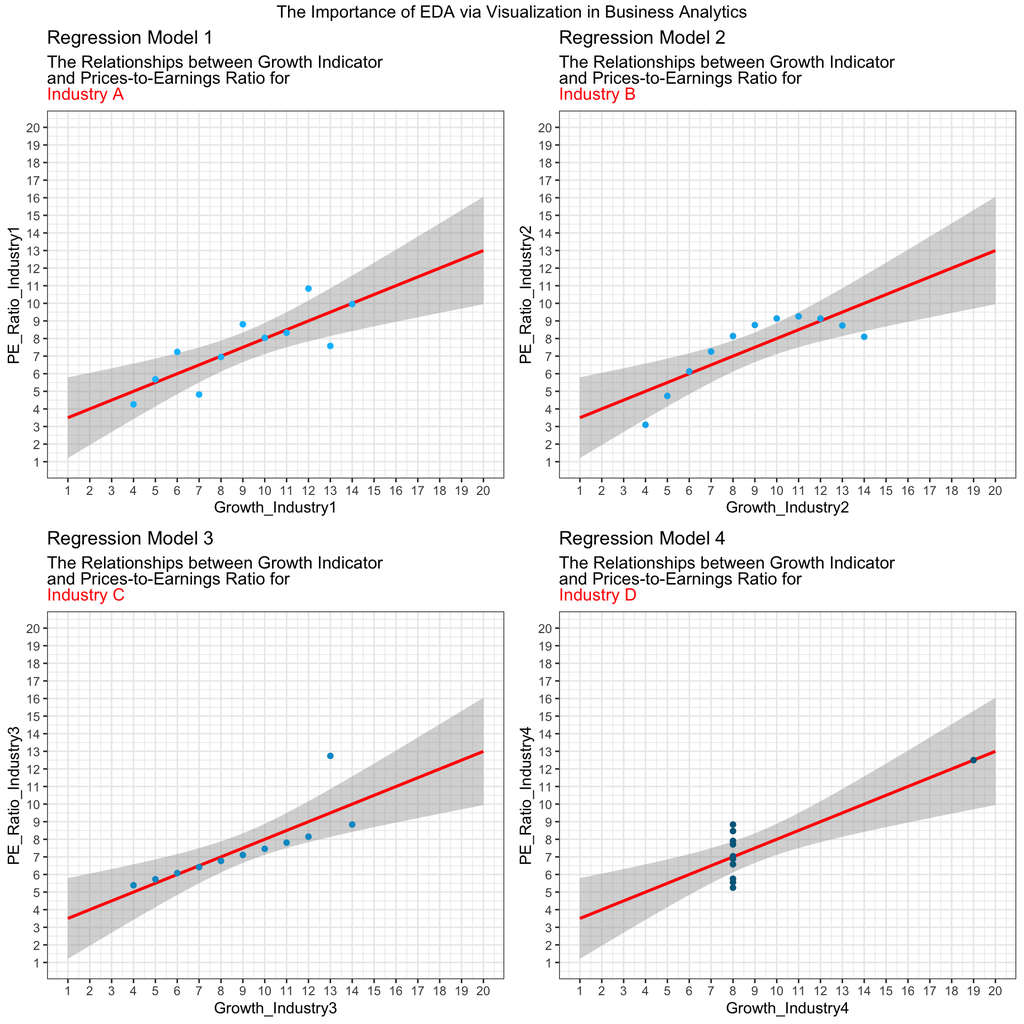

> The lesson here is simply that `summary statistics don’t tell the whole insights in business analytics`.

# 4. Turn Data into `Insight`

> Now you might want to fit your data for `Industry B` with a curvilinear (quadratic equation), as shown below.

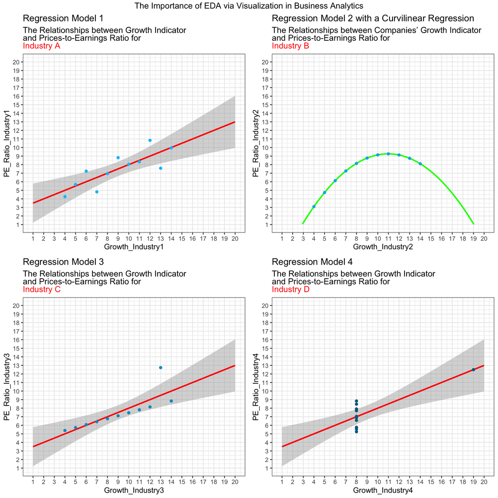

> Here, an exploratory data analysis, using visualization of your data, tells you to employ a better modeling strategy for fitting your data. Otherwise you might have suffered a missed opportunity, which often turns into a costly, ill-guided business decision.
- By now you might think that `data visualization` applies only to exploratory questions. `Nope`, it is widely used for inferential, causal, and predictive questions `as a preparatory analytic work`.

**💯 “Thank you for bringing your souls to our class” 😊**